# VLM Wrong Predictions: attr_abutment_material [embed_only]

**Model:** VLM vs DINOv3  
**Attribute:** attr_abutment_material [embed_only]  
**Wrong assets:** 15 of 15 (100.0% asset-level error rate)

Asset 49060 4 images

Predicted: VLM: Concrete | DINOv3: Timber (conf: N/A)

Actual: Timber

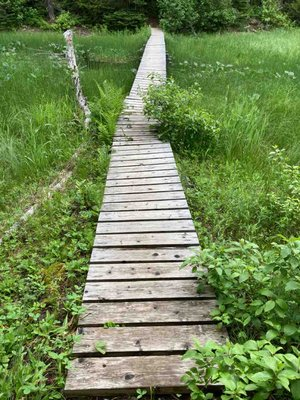

52793__AST_EX_20220707_124156.jpeg

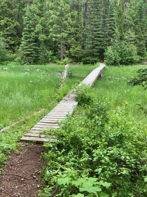

52796__AST_EX_20220707_124145.jpeg

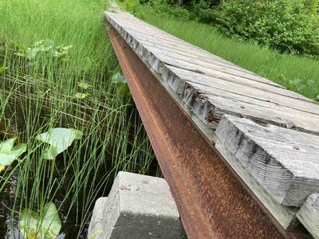

52797__AST_EX_20220707_124315.jpeg

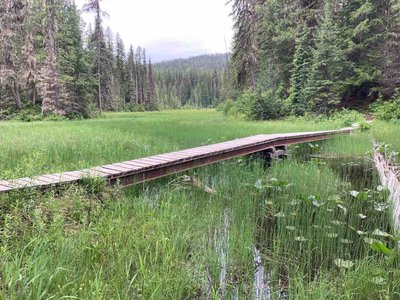

52813__AST_EX_20220707_124357.jpeg

Asset 51524 1 image

Predicted: VLM: unable to determine | DINOv3: Concrete (conf: N/A)

Actual: Concrete

[figure not shown]

16914__AST_EX_20210820_142024.jpeg

Asset 53986 1 image

Predicted: VLM: unable to determine | DINOv3: Timber (conf: N/A)

Actual: Timber

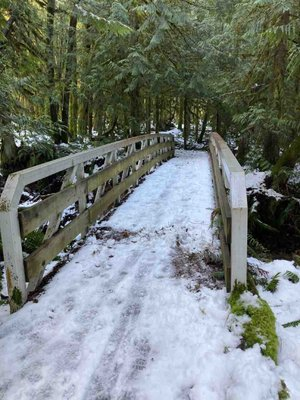

64713__AST_EX_20230302_102311.jpeg

Asset 61003 1 image

Predicted: VLM: unable to determine | DINOv3: Timber (conf: N/A)

Actual: Timber

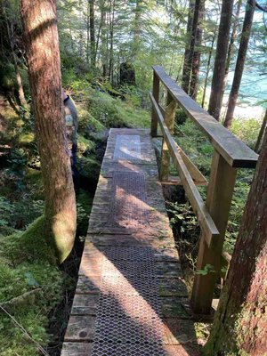

88959__AST_EX_20250924_140750.jpeg

Asset 64102 1 image

Predicted: VLM: Timber | DINOv3: Concrete (conf: N/A)

Actual: Concrete

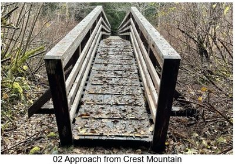

84320__asset64102_approachfromCrestMtn.jpg

Asset 83150 3 images

Predicted: VLM: Gabions | DINOv3: Timber (conf: N/A)

Actual: Timber

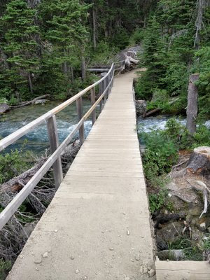

6703__MI_20210716_105250.jpg

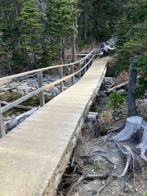

82701__AST_EX_20250525_112831.jpeg

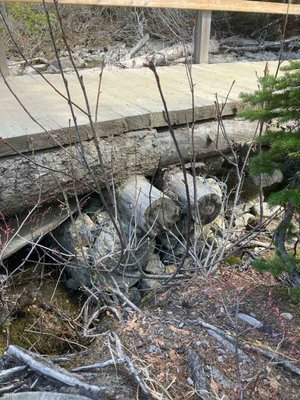

82702__AST_EX_20250525_112857.jpeg

Asset 86369 1 image

Predicted: VLM: Timber | DINOv3: Concrete (conf: N/A)

Actual: Concrete

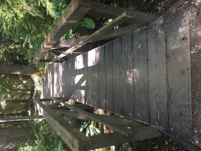

13497__AST_IM_20210812_123750.jpeg

Asset 86525 1 image

Predicted: VLM: Timber | DINOv3: Concrete (conf: N/A)

Actual: Concrete

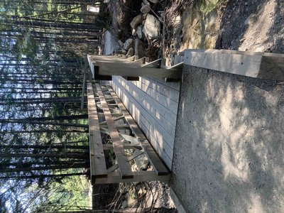

13953__AST_IM_20210812_112957.jpeg

Asset 89437 1 image

Predicted: VLM: unable to determine | DINOv3: Timber (conf: N/A)

Actual: Timber

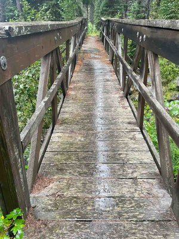

22179__AST_IM_20210918_120140.jpeg

Asset 89450 1 image

Predicted: VLM: unable to determine | DINOv3: Timber (conf: N/A)

Actual: Timber

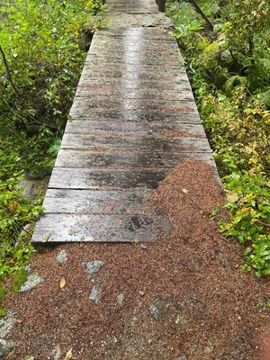

22183__AST_IM_20210918_115908.jpeg

Asset 89580 1 image

Predicted: VLM: unable to determine | DINOv3: Timber (conf: N/A)

Actual: Timber

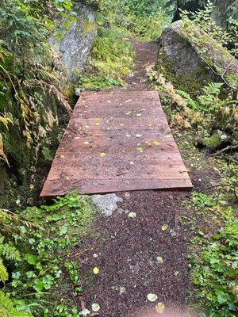

22595__AST_IM_20210919_104037.jpeg

Asset 92801 3 images

Predicted: VLM: unable to determine | DINOv3: Timber (conf: N/A)

Actual: Timber

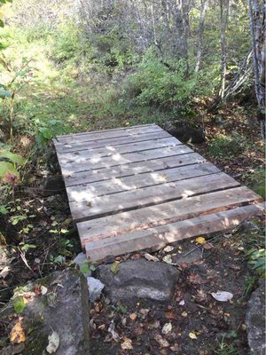

29224__AST_IM_20211012_113547.jpeg

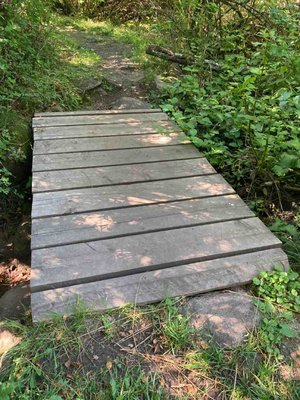

55915__AST_EX_20220726_094520.jpeg

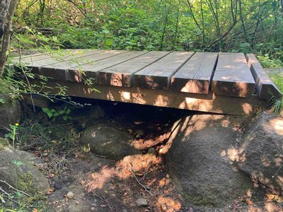

55918__AST_EX_20220726_094541.jpeg

Asset 93043 1 image

Predicted: VLM: unable to determine | DINOv3: Timber (conf: N/A)

Actual: Timber

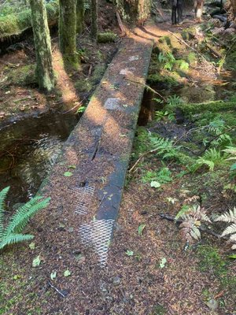

29697__AST_IM_20211029_132630.jpeg

Asset 94144 1 image

Predicted: VLM: Timber | DINOv3: Concrete (conf: N/A)

Actual: Concrete

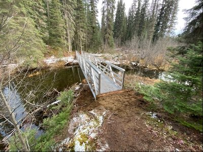

32678__Babcock_Bridge___2.jpg

Asset 94177 1 image

Predicted: VLM: unable to determine | DINOv3: Timber (conf: N/A)

Actual: Timber

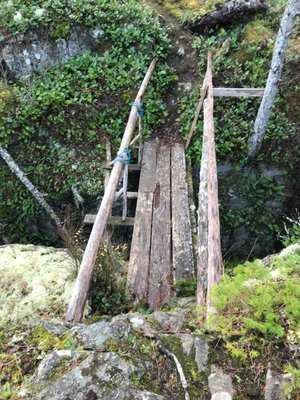

33072__AST_IM_20211126_123608.jpeg